# Example 3: Conditional reliabilities of three measures

Accuracy of person estimates at a given point in the trait distribution

Author

Ulrich Schroeders & Timo Gnambs

Published

December 26, 2024

# Objective

The example demonstrates how to identify the sample size required to estimate the conditional reliability of a test using the graded response model (GRM; [Samejima, 1969](https://doi.org/10.1007/BF03372160)) with a given precision. It is assumed that respondents are randomly administered two out of three depression instruments, that is, the 21-item *Beck’s Depression Inventory-II* (BDI-II), the 20-item *Center for Epidemiological Studies Depression Scale* (CES-D), and 9-item the *Patient Health Questionnaire* (PHQ). These instruments are intended to screen patients for clinically relevant levels of depression. Therefore, the focus is on the measurement precision, that is conditional reliability, at two standard deviations above the mean.

# I. Determining the data generation for the complete dataset

1. Number and distribution of factors (unidimensional vs. multidimensional)
2. Number of items and item parameters (discriminations, difficulties)
3. Item type (dichotomous, polytomous)

A total of 50 items are included in the three measurement instruments. All items are answered on a four-point, ordered response scale, for example, CESD-1 “I was bothered by things that usually don’t bother me” from 0 (*Rarely or none of the time*) to 3 (*Most or all of the time*). The values for item discrimination ($a$) and item difficulty ($b$) are taken from Table 3 in [Choi et al. (2014)](https://doi.org/10.1037/a0035768).

```r
# Clear work space and load necessary packages
rm(list = ls())
library(tidyverse)   # General data handling and manipulation
library(mirt)        # Estimate item response model

# Set the seed for random number generation to ensure reproducibility
set.seed(2024)

# Load item parameters from file
item_parameter <- rio::import("choi_grm.xlsx")
a_i <- item_parameter$a
b_i <- item_parameter[, c("b1", "b2", "b3")] %>% as.matrix()
item_names <- item_parameter$Item
```

The function `generate_grm_data` uses `mirt::simdata` to simulate polytomous data given the item discriminations ($a$), the item difficulties ($b$), and the sample size ($n$). For polytomous items (i.e., multiple ordered categories) in the GRM, the probability of obtaining a category score is given by:

$$P(X_{pi} \geq k | a_i, b_{ik}, \theta_p) = \frac{1}{1 + \exp(-a_i(\theta_p - b_{ik}))}$$

where $b_{ik}$ is the threshold parameter for modeling the probability of scoring at or above category $k$ on item $i$. As a reminder, the `mirt` package uses a matrix of intercepts ($d$) as input, so that the item difficulties have to be transformed ($d = -a*b$).

```r
# Simulate graded item responses for n respondents to all items
# - 'a' denotes the item discriminations
# - 'b' denotes and the category thresholds
# - 'n' denotes the number of observations

generate_grm_data <- function(a, b, n) {
  resp <-
    simdata(a = a,
            d = -a*b,
            N = n,
            itemtype = "graded") %>%
    as.data.frame()
  colnames(resp) <- item_parameter$Item

  return(resp)
}
```

# II. Defining the test design and the process of missing values

4. Pattern of missingness (e.g., type of missingness, linking design)
5. Amount of missing data

In the present case, we assume a simple test design in which each test taker completes exactly two measurement instruments. Therefore, the function `data_lomo_design` leaves one measure out (i.e., select the other two).

```r
# Select two out of three measures
# - 'resp' denotes the complete data set

data_lomo_design <- function(resp) {
  n_per_test <- floor(nrow(resp) / 3)

  resp <- resp %>%
    mutate(across(!starts_with("CESD"), ~replace(., 1:n_per_test, NA))) %>%
    mutate(across(!starts_with("PHQ"), ~replace(., (n_per_test+1):(2 * n_per_test), NA))) %>%
    mutate(across(!starts_with("BDI"), ~replace(., (2 * n_per_test+1):n(), NA)))

  return(resp)
}
```

# III. Selecting the IRT model and the parameter of interest

6. Underlying IRT model (e.g., 1PL, 2PL)
7. IRT modeling software and estimation method
8. Parameters to extract

```r
# Estimate item response model
# - 'resp' denotes the data set

estimate_irt <- function(resp) {

  # Estimate a graded response model (GRM) using try-catch to handle errors
  mod <- tryCatch(
    mirt(data = resp, 1,
         itemtype = "graded",                        # unidimensional GRM model
         verbose = FALSE),
    error = function(e) NULL
  )

  # Calculate the conditional reliabilities if the model is successfully estimated
  est <- if (!is.null(mod)) {
    tinfo <- testinfo(mod, Theta = seq(-4, 4, 0.1))  # get the test information
    rel = tinfo / (tinfo + 1)                        # conditional reliability
  } else {
    rel = NA
  }
  est <- data.frame(theta = seq(-4, 4, 0.1), rel = rel)
  return(est)
}
```

# IV. Setting up the Monte Carlo Simulation

9. Number of iterations
10. Sample sizes to evaluate

The Monte Carlo simulation runs `n_iterations` times, including the previous steps of (i) determining the data generation for the complete dataset, (ii) defining the test design and the process of missing values, (iii) selecting the IRT model and the parameter of interest. The simulation is run for different total sample sizes between 300 and 1050 (in increments of 75). Due to the chosen test design the sample size for each individual measure is 2/3 of the total sample size.

Using an estimated standard deviation for the RMSE of the estimated reliability ($\sigma = 0.012$) derived from 500 iterations, a specified level of accuracy ($\delta = .001$), and a significance level ($\alpha = .05$), the number of iterations required is approximately 553.

```r
# Number of iterations
n_iterations <- 553

# Create data frame for results (res)
res <- data.frame()

# Check if result file already exists
if (file.exists("example_3_res.rds")) {
  res <- readRDS("example_3_res.rds")
} else {
  # Loop over different sample sizes (from 300 to 1050, in steps of 75)
  for (n_persons in seq(300, 1050, 75)) {

    # Nested loop, running 'n_iterations' times
    for (iter in 1:n_iterations) {

      dat <- generate_grm_data(a_i, b_i, n_persons) %>%
        data_lomo_design()
      rel1 <- dat %>% dplyr::select(starts_with("PHQ")) %>%
        na.omit %>% estimate_irt %>% filter(theta==2.0) %>% pull(rel)
      rel2 <- dat %>% dplyr::select(starts_with("BDI")) %>%
        na.omit %>% estimate_irt %>% filter(theta==2.0) %>% pull(rel)
      rel3 <- dat %>% dplyr::select(starts_with("CESD")) %>%
        na.omit %>% estimate_irt %>% filter(theta==2.0) %>% pull(rel)

      # Create result set with iter, N, and the estimated reliabilities
      res <- bind_rows(res,
                       data.frame(iteration = iter,
                                  n_persons = n_persons,
                                  rel_phq = rel1,
                                  rel_bdi = rel2,
                                  rel_cesd = rel3))
    }
  }

  # Save the results
  saveRDS(res, file = "example_3_res.rds")
}
```

# Results

The figure shows the accuracy of the conditional reliability estimate at the boundary between moderate and severe symptom severity for all three depression measures. We use the root mean square error of the reliability, $\mathrm{RMSE}(\rho) = \sqrt{M((\rho_{\text{est}} - \rho_{\text{true}})^2)}$, at a given theta value ($\theta = 2.0$).

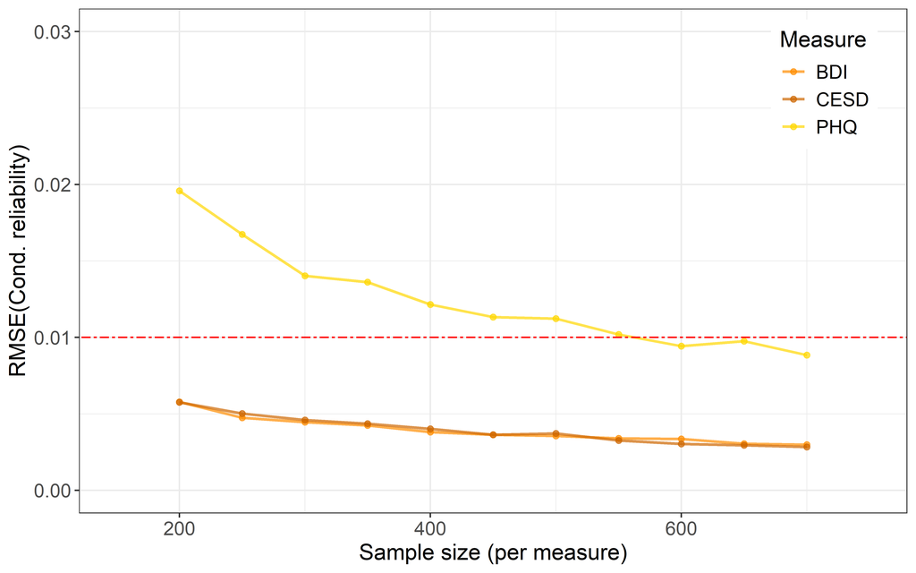

```r
# The function estimates the conditional reliability at a given point in the
  # trait distribution (theta). Specifically, a response matrix 'resp' is
  # generated with columns representing items, then a parameter object 'pars'
  # for a graded response model is initiated using the mirt The discrimination
  # parameters 'a' and the threshold parameters 'b' are assigned to 'pars'.
  # The parameters are fixed  - not estimated - by setting 'pars$est' to FALSE.

rel_true <- function(a, b, theta) {
  # Fixed item parameters
  resp <- matrix(rep(seq_len(ncol(b) + 1), length(a)), ncol = length(a))
  colnames(resp) <- paste0("i", seq_len(ncol(resp)))
  pars <- mirt(data = resp, 1, itemtype = "graded", pars = "values")
  pars$value[pars$name == "a1"] <- a
  pars$value[grepl("^d", pars$name)] <- c(t(-a*b))
  pars$est <- FALSE

  # Model with fixed item parameters
  mod <- mirt(data = resp, itemtype = "graded",
              pars = pars, verbose = FALSE)

  # Conditional reliability
  tinf <- testinfo(mod, Theta = theta)
  rel <- tinf / (1 + tinf)
  return(rel)
}

# Extract item parameters for the depression measures
ipar_phq <- item_parameter %>% filter(str_starts(Item, "PHQ"))
ipar_bdi <- item_parameter %>% filter(str_starts(Item, "BDI"))
ipar_cesd <- item_parameter %>% filter(str_starts(Item, "CESD"))

# Calculate true reliabilities of the depression measures
rel_true_phq <- rel_true(ipar_phq$a, ipar_phq[, c("b1", "b2", "b3")], 2.0)
rel_true_bdi <- rel_true(ipar_bdi$a, ipar_bdi[, c("b1", "b2", "b3")], 2.0)
rel_true_cesd <- rel_true(ipar_cesd$a, ipar_cesd[, c("b1", "b2", "b3")], 2.0)

# Preparation and aggregation of results
res_plot <- res %>%
  group_by(n_persons) %>%
  summarise(
    RMSE_rel_phq = sqrt(mean((rel_phq - rel_true_phq)^2)),    # RMSE rel(PHQ)
    RMSE_rel_bdi = sqrt(mean((rel_bdi - rel_true_bdi)^2)),    # RMSE rel(BDI)
    RMSE_rel_cesd = sqrt(mean((rel_cesd - rel_true_cesd)^2)), # RMSE rel(CESD)
    .groups = 'drop')

# Plot the RMSE for the reliability estimates across measures
  # n_persons/3*2 = sample size per measure
ggplot(data=res_plot, aes(x=n_persons/3*2)) +
  geom_line(aes(y = RMSE_rel_phq, color = "PHQ"), linewidth = 0.8, alpha = 0.7) +
  geom_point(aes(y = RMSE_rel_phq, color = "PHQ"), size = 1.5, alpha = 0.7) +
  geom_line(aes(y = RMSE_rel_bdi, color = "BDI"), linewidth = 0.8, alpha = 0.7) +
  geom_point(aes(y = RMSE_rel_bdi, color = "BDI"), size = 1.5, alpha = 0.7) +
  geom_line(aes(y = RMSE_rel_cesd, color = "CESD"), linewidth = 0.8, alpha = 0.7) +
  geom_point(aes(y = RMSE_rel_cesd, color = "CESD"), size = 1.5, alpha = 0.7) +
  scale_color_manual(
    values = c("PHQ" = "gold",
               "BDI" = "darkorange",
               "CESD" = "darkorange3"),
    labels = c("PHQ" = "PHQ",
               "BDI" = "BDI",
               "CESD" = "CESD")
  ) +
  geom_abline(intercept = .01, slope = 0, col="red", lty = "twodash") +
  labs(
    x = "Sample size (per measure)",
    y = "RMSE(Cond. reliability)",
    color = "Measure"
  ) +
  ylim(0, 0.03) +
  xlim(150, 750) +
  theme_bw() +
  theme(
    axis.title = element_text(size = 14),
    axis.text = element_text(size = 12),
    legend.title = element_text(size = 14),
    legend.text = element_text(size = 12),
    legend.position = "inside",
    legend.position.inside =  c(.90, .85)
  )
```